# Project Data Exploration and Preprocessing

STATS503, WN21

Yanyu Long

Apr 14, 2021

## Summary

- On the weather dataset
  - I converted the hourly weather data to monthly summary statistics. See the reshaping weather data subsection for details.
- On the storm event dataset
  - We will only look at events reported by counties (CZ_TYPE == ‘C’) and drop those reported by forecast zones (CZ_TYPE == ‘Z’).
  - One `episode_id` can correspond to multiple `event_id`s. I used episodes as the unit of extreme weather events - multiple events with the same `episode_id` are considered to be one event.
  - I aggregated the event data to monthly records - the number of episodes in a county in a month. See the wind storm dataset section.
- On merging the two datasets
  - The number of extreme weather events (# of episodes) were aggregated on the county level, while the weather records were observed in cities and used as an approximation for county-level weather status. Our analysis and discussion should be on the county level.
  - I prepared two merging approaches, one matches the storm events to the weather data in the same month (can be used for in-time “predictions”), the other matches storm events to the weather data in the previous month (can be used for forecasting). The two approaches correspond to the two versions of final outputs `windstorm_weather_same_month.RData` and `windstorm_weather_prev_month.RData`. They can be used directly for model training.
  - See the merging windstorm and weather datasets section for details.

## Hourly weather dataset

- Data Source: [Historical Weather Dataset on 30 US & Canada cities: 2012-2017](https://www.kaggle.com/selfishgene/historical-hourly-weather-data).
- The 27 U.S. cities we have weather records for:

| state | county | city | state | county | city |
| --- | --- | --- | --- | --- | --- |
| Oregon | Multnomah | Portland | Missouri | St. Louis | Saint Louis |
| California | San Francisco | San Francisco | Illinois | Cook | Chicago |
| Washington | King | Seattle | Tennessee | Davidson | Nashville |
| California | Los Angeles | Los Angeles | Indiana | Marion | Indianapolis |
| California | San Diego | San Diego | Georgia | Fulton | Atlanta |
| Nevada | Clark | Las Vegas | Michigan | Wayne | Detroit |
| Arizona | Maricopa | Phoenix | Florida | Duval | Jacksonville |
| New Mexico | Bernalillo | Albuquerque | North Carolina | Mecklenburg | Charlotte |
| Colorado | Denver | Denver | Florida | Miami-Dade | Miami |
| Texas | Bexar | San Antonio | Pennsylvania | Allegheny | Pittsburgh |
| Texas | Dallas | Dallas | Pennsylvania | Philadelphia | Philadelphia |
| Texas | Harris | Houston | New York | New York | New York |
| Missouri | Jackson | Kansas City | Massachusetts | Suffolk | Boston |
| Minnesota | Hennepin | Minneapolis |  |  |  |

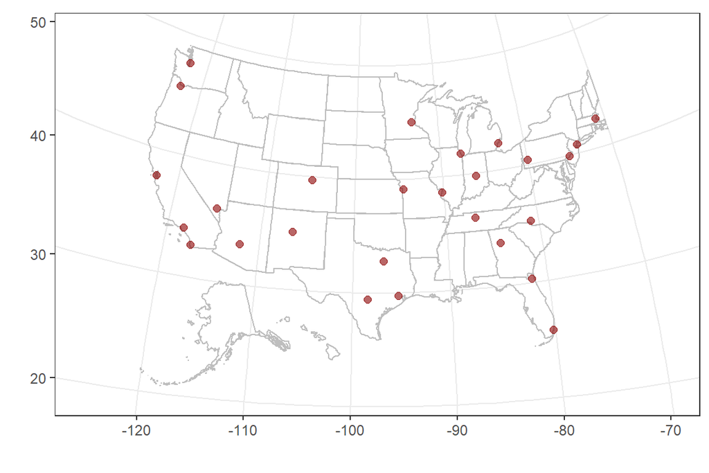

27 U.S. Cities

### Reshaping weather data

The weather dataset contains hourly observations for humidity, pressure, temperature, wind direction, and wind speed, all of which are numeric variables. I did the following transformation:

- For humidity, pressure, wind direction, and wind speed:
  - convert hourly data to daily mean values
  - compute monthly average and standard deviation of the daily mean values

Take humidity as an example.

#### The original data

| datetime | Portland | San Francisco | Seattle | Los Angeles | San Diego |
| --- | --- | --- | --- | --- | --- |
| 2012-10-01 12:00:00 |  |  |  |  |  |
| 2012-10-01 13:00:00 | 81 | 88 | 81 | 88 | 82 |
| 2012-10-01 14:00:00 | 80 | 87 | 80 | 88 | 81 |
| 2012-10-01 15:00:00 | 80 | 86 | 80 | 88 | 81 |
| 2012-10-01 16:00:00 | 80 | 85 | 79 | 88 | 81 |
| 2012-10-01 17:00:00 | 79 | 84 | 79 | 88 | 80 |

#### Compute daily means

| date | city | humidity |
| --- | --- | --- |
| 2012-10-01 | Portland | 78.72727 |
| 2012-10-02 | Portland | 65.83333 |
| 2012-10-03 | Portland | 66.20833 |
| 2012-10-04 | Portland | 51.16667 |
| 2012-10-05 | Portland | 40.39130 |
| 2012-10-06 | Portland | 40.75000 |

#### Compute monthly average and sd

| ym | city | humidity_avg | humidity_sd |
| --- | --- | --- | --- |
| 2012-10 | Portland | 72.68403 | 16.991678 |
| 2012-11 | Portland | 83.52227 | 6.926699 |
| 2012-12 | Portland | 86.07985 | 4.548216 |
| 2013-01 | Portland | 81.90679 | 10.694849 |
| 2013-02 | Portland | 81.29739 | 5.711051 |
| 2013-03 | Portland | 75.31799 | 8.776971 |

- For temperature:
  - convert hourly observations to (i) daily mean temperature `meantemp` and (ii) diurnal temperature variation `difftemp` (the difference between the max and min temperature within a day)
  - compute monthly average values and standard deviations of the daily mean temperatures and diurnal variations

After transformation:

| ym | city | meantemp_avg | difftemp_avg | meantemp_sd | difftemp_sd |
| --- | --- | --- | --- | --- | --- |
| 2012-10 | Albuquerque | 287.0911 | 13.988084 | 3.779363 | 3.621679 |
| 2012-10 | Atlanta | 289.5540 | 9.677601 | 3.427436 | 4.574573 |
| 2012-10 | Boston | 286.0031 | 8.069497 | 3.409443 | 4.155983 |
| 2012-10 | Charlotte | 288.7042 | 10.650447 | 3.517333 | 4.756726 |
| 2012-10 | Chicago | 284.6265 | 8.173461 | 4.636008 | 3.881604 |
| 2012-10 | Dallas | 292.1314 | 10.156523 | 5.428272 | 3.997007 |

## Wind storm dataset

- Data source: [National Centers for Environmental Information (NOAA)](https://www1.ncdc.noaa.gov/pub/data/swdi/stormevents/csvfiles/)
- Time frame: 2012-2017 (to match the hourly weather dataset)

There are two types of records in the wind storm datasets: some events are reported by forecast zone (CZTYPE of “Z”), others by county (CZTYPE of “C”). We will only look at events reported by counties, but here are some examples for both types.

Events reported by forecast zones (‘Z’)

| EPISODE_ID | EVENT_ID | BEGIN_YEARMONTH | BEGIN_DAY | STATE | CZ_NAME | EVENT_TYPE |
| --- | --- | --- | --- | --- | --- | --- |
| 121068 | 724772 | 201710 | 22 | GULF OF MEXICO | ATCHAFALAYA R TO INTRACOASTAL CITY LA OUT 20NM | Marine Thunderstorm Wind |
| 120474 | 721817 | 201710 | 24 | ATLANTIC NORTH | DE BAY WATERS S OF E PT NJ TO SLAUGHTER BEACH DE | Marine Strong Wind |
| 120474 | 721818 | 201710 | 24 | ATLANTIC NORTH | DE BAY WATERS N OF E PT NJ TO SLAUGHTER BEACH DE | Marine High Wind |
| 112855 | 675876 | 201703 | 10 | PENNSYLVANIA | MONROE | Winter Weather |

Events reported by counties (‘C’) - `CZ_NAME`s are county names

| EPISODE_ID | EVENT_ID | BEGIN_YEARMONTH | BEGIN_DAY | STATE | CZ_NAME | EVENT_TYPE |
| --- | --- | --- | --- | --- | --- | --- |
| 113355 | 678791 | 201704 | 6 | NEW JERSEY | GLOUCESTER | Thunderstorm Wind |
| 113459 | 679228 | 201704 | 6 | FLORIDA | LEE | Tornado |
| 113448 | 679268 | 201704 | 5 | OHIO | GREENE | Thunderstorm Wind |
| 113697 | 682042 | 201704 | 16 | OHIO | CLERMONT | Flood |

One `episode_id` can correspond to multiple `event_id`s. In 2017, 151 events were recorded under the episode ID `115177`, all of which happened during May 26-28. The episode narrative reads: “Multiple rounds of severe thunderstorms brought damaging straight-line winds, large hail, tornadoes, and flooding to the Missouri Ozarks from May 27th into the early morning hours of May 28th. Over 130 reports of severe weather and flooding were received from the Missouri Ozarks.” In the following data analysis, we will use episodes as the unit of extreme weather events. For example, we consider the episode 115177 to be one extreme weather event.

Events with `episode_id` 115117

| episode_id | event_id | ym | day | state | county | event_type |
| --- | --- | --- | --- | --- | --- | --- |
| 115177 | 697792 | 201705 | 26 | MISSOURI | HICKORY | Hail |
| 115177 | 697793 | 201705 | 26 | MISSOURI | HICKORY | Hail |
| 115177 | 697794 | 201705 | 26 | MISSOURI | HICKORY | Hail |
| 115177 | 697795 | 201705 | 26 | MISSOURI | TEXAS | Hail |
| 115177 | 697796 | 201705 | 26 | MISSOURI | LACLEDE | Hail |
| 115177 | 697797 | 201705 | 26 | MISSOURI | DALLAS | Hail |
| 115177 | 697798 | 201705 | 26 | MISSOURI | TEXAS | Hail |
| 115177 | 698016 | 201705 | 27 | MISSOURI | HOWELL | Thunderstorm Wind |

Here is a heat map for the cumulative number of extreme weather event episodes from 2012 to 2017 in each state. Texas had a total of 3,750 episodes and ranked first among the states.

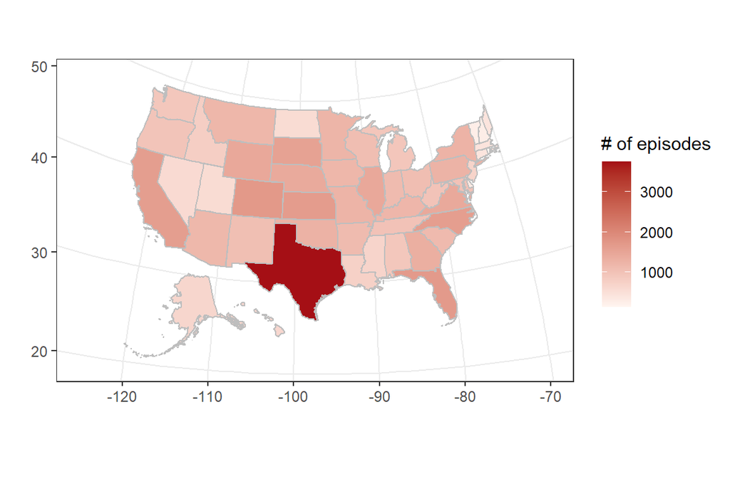

Cumulative number of extreme weather events (episodes) in each state, 01/2012 - 12/2017

### Reshaping storm event data

Reshaping storm event data is relatively straightforward. We keep the events observed by counties, compute the number of episodes observed in each county in each month from 2012 to 2017. The transformed data look like:

| state | county | ym | num_episodes |
| --- | --- | --- | --- |
| ALABAMA | AUTAUGA | 201202 | 1 |
| ALABAMA | AUTAUGA | 201203 | 1 |
| ALABAMA | AUTAUGA | 201204 | 1 |
| ALABAMA | AUTAUGA | 201205 | 1 |
| ALABAMA | AUTAUGA | 201207 | 3 |
| ALABAMA | AUTAUGA | 201212 | 1 |

## Merging windstorm and weather datasets

Note that the windstorm records are uniquely identified by counties and time (year-month), while the weather data are uniquely identified cities and time. We will be using city-level weather records to represent county-level climate status. To merge the two datasets, we need to match the 27 U.S. cities in the weather dataset to the counties they are in. We do that with the help of the [US Cities Database](https://simplemaps.com/data/us-cities).

To address this comment on our project proposal:

> Do you plan to do forecasting or in-time “prediction”? If it’s the latter, why it’s interesting, as we already know it’s happening?

I prepared two merging approaches, one matches the storm events to the weather data in the same month, the other matches storm events to the weather data in the previous month. They both have the same format - 1,674 rows (62 months $\times$ 27 cities) and 17 columns. Take the first version as an example:

```r
load("data/windstorm_weather_same_month.RData")
data_merged %>% dim
```

```
[1] 1674   17
```

```r
data_merged %>% colnames
```

```
 [1] "ym"                 "city"               "county"             "state"
 [5] "num_episodes"       "meantemp_avg"       "difftemp_avg"       "meantemp_sd"
 [9] "difftemp_sd"        "humidity_avg"       "humidity_sd"        "pressure_avg"
[13] "pressure_sd"        "wind_direction_avg" "wind_direction_sd"  "wind_speed_avg"
[17] "wind_speed_sd"
```

```r
data_merged %>% head()
```

| ym | city | county | state | num_episodes | meantemp_avg | difftemp_avg | meantemp_sd | difftemp_sd | humidity_avg |
| --- | --- | --- | --- | --- | --- | --- | --- | --- | --- |
| 2012-10 | Albuquerque | Bernalillo | New Mexico | 0 | 287.0911 | 13.988084 | 3.779363 | 3.621679 | 29.01159 |
| 2012-10 | Atlanta | Fulton | Georgia | 0 | 289.5540 | 9.677601 | 3.427436 | 4.574573 | 71.63047 |
| 2012-10 | Boston | Suffolk | Massachusetts | 1 | 286.0031 | 8.069497 | 3.409443 | 4.155983 | 73.28394 |
| 2012-10 | Charlotte | Mecklenburg | North Carolina | 1 | 288.7042 | 10.650447 | 3.517333 | 4.756726 | 70.75719 |
| 2012-10 | Chicago | Cook | Illinois | 1 | 284.6265 | 8.173461 | 4.636008 | 3.881604 | 62.01605 |
| 2012-10 | Dallas | Dallas | Texas | 0 | 292.1314 | 10.156523 | 5.428272 | 3.997007 | 61.92640 |

Note that the number of episodes were aggregated on the county level, while the weather records were observed in cities and used as an approximation for county-level weather status. So the analysis and discussion should be on the county level.

We are likely going to look into a classification problem, so we can transform `num_episodes` to a 0-1 variable `event` (0 for no extreme weather events and 1 otherwise). This is a relatively balanced dataset:

```r
data_merged = data_merged %>% mutate(event = ifelse(num_episodes > 0, 1, 0))
table(data_merged$event)
```

```
  0   1
937 737
```

### match windstorm to weather in the same month

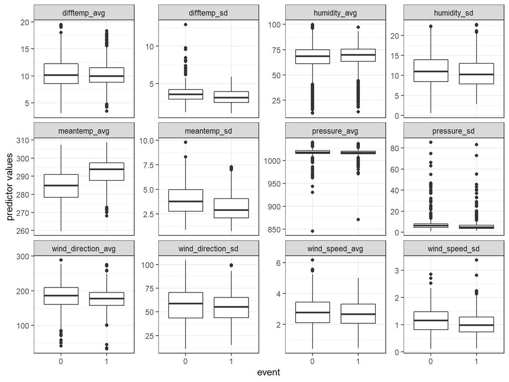

### match windstorm to weather in the previous month

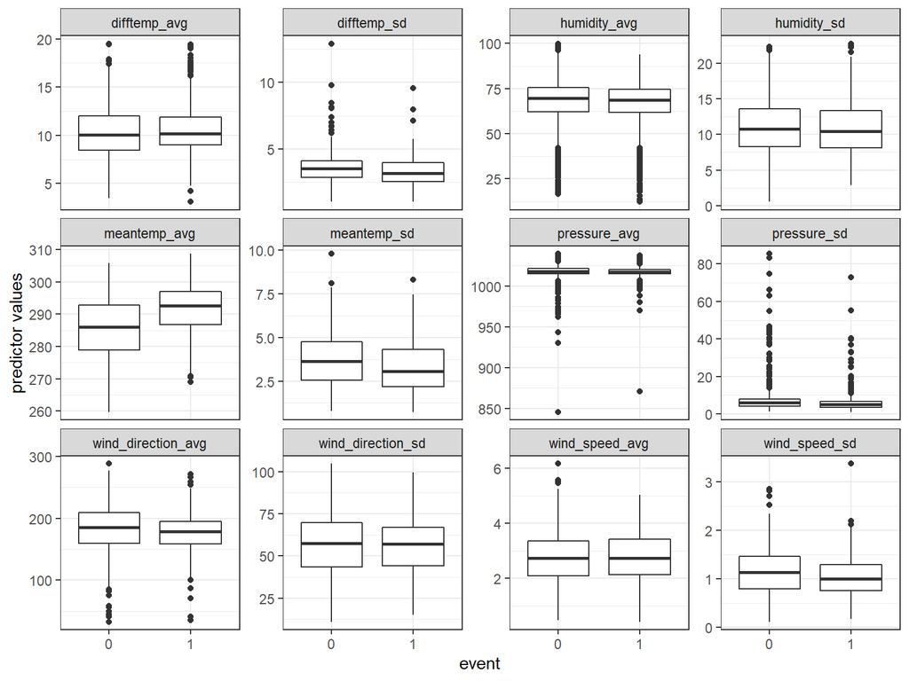